# E14.5 cortex

```r
library(COTAN)
library(data.table)
library(Matrix)
library(ggrepel)
#library(latex2exp)
```

```r
mycolours <- c("A" = "#8491B4B2","B"="#E64B35FF")
my_theme = theme(axis.text.x = element_text(size = 14, angle = 0, hjust = .5, vjust = .5, face = "plain", colour ="#3C5488FF" ),
                 axis.text.y = element_text( size = 14, angle = 0, hjust = 0, vjust = .5, face = "plain", colour ="#3C5488FF"),
                 axis.title.x = element_text( size = 14, angle = 0, hjust = .5, vjust = 0, face = "plain", colour ="#3C5488FF"),
                 axis.title.y = element_text( size = 14, angle = 90, hjust = .5, vjust = .5, face = "plain", colour ="#3C5488FF"))
```

```r
data_dir = "Data/Mouse2/"
```

```r
data = as.data.frame(fread(paste(data_dir,"GSE123335_E14_combined_matrix.txt.gz", sep = "/")))
data = as.data.frame(data)
rownames(data) = data$Gene
data = data[,2:ncol(data)]
data[1:10,1:10]
```

|  | e14-WT10_AAAAAGCAAGAA | e14-WT10_AAAAATCTCTCC | e14-WT10_AAAACACATTCC | e14-WT10_AAAACCGTGGAT | e14-WT10_AAAACGCGCCGA | e14-WT10_AAAAGAGCCGAG | e14-WT10_AAAATGGACTCA | e14-WT10_AAAATGTCACAA | e14-WT10_AAAATTCCGCTT | e14-WT10_AAAATTGCAGAG |
| --- | --- | --- | --- | --- | --- | --- | --- | --- | --- | --- |
| 0610005C13Rik | 0 | 0 | 0 | 0 | 0 | 0 | 0 | 0 | 0 | 0 |
| 0610007N19Rik | 0 | 0 | 0 | 0 | 0 | 0 | 0 | 0 | 0 | 0 |
| 0610007P14Rik | 0 | 1 | 0 | 0 | 0 | 0 | 0 | 0 | 0 | 0 |
| 0610009B14Rik | 0 | 0 | 0 | 0 | 0 | 0 | 0 | 0 | 0 | 0 |
| 0610009B22Rik | 0 | 0 | 0 | 0 | 0 | 0 | 0 | 0 | 1 | 1 |
| 0610009D07Rik | 1 | 0 | 0 | 0 | 0 | 1 | 2 | 0 | 1 | 1 |
| 0610009E02Rik | 0 | 0 | 0 | 0 | 0 | 0 | 0 | 0 | 0 | 0 |
| 0610009L18Rik | 0 | 0 | 0 | 0 | 0 | 0 | 0 | 0 | 0 | 0 |
| 0610009O20Rik | 0 | 0 | 0 | 0 | 0 | 0 | 0 | 0 | 0 | 0 |
| 0610010F05Rik | 0 | 0 | 0 | 1 | 1 | 0 | 0 | 3 | 0 | 0 |

Define a directory where the ouput will be stored.

```r
out_dir = "Data/"
```

## 0.1 Analytical pipeline

Initialize the COTAN object with the row count table and the metadata for the experiment.

```r
obj = new("scCOTAN",raw = data)
obj = initRaw(obj,GEO="GSE123335" ,sc.method="10X",cond = "mouse cortex E14.5")
```

```
[1] "Initializing S4 object"
```

Now we can start the cleaning. Analysis requires and starts from a matrix of raw UMI counts after removing possible cell doublets or multiplets and low quality or dying cells (with too high mtRNA percentage, easily done with Seurat or other tools).

If we do not want to consider the mithocondrial genes we can remove them before starting the analysis.

```r
genes_to_rem = rownames(obj@raw[grep('^mt', rownames(obj@raw)),]) #genes to remove : mithocondrial
obj@raw = obj@raw[!rownames(obj@raw) %in% genes_to_rem,]
cells_to_rem = colnames(obj@raw[which(colSums(obj@raw) == 0)])
obj@raw = obj@raw[,!colnames(obj@raw) %in% cells_to_rem]
```

We want also to define a prefix to identify the sample.

```r
t = "E14_cortex"

print(paste("Condition ",t,sep = ""))
```

```
[1] "Condition E14_cortex"
```

```r
#--------------------------------------
n_cells = length(colnames(obj@raw))
print(paste("n cells", n_cells, sep = " "))
```

```
[1] "n cells 11069"
```

```r
n_it = 1

#obj@raw = obj@raw[rownames(cells), colnames(cells)]
```

## 0.2 Data cleaning

First, we create the directory to store all information regarding the data cleaning.

```r
if(!file.exists(out_dir)){
  dir.create(file.path(out_dir))
}

if(!file.exists(paste(out_dir,"cleaning", sep = ""))){
  dir.create(file.path(out_dir, "cleaning"))
}
```

```r
ttm = clean(obj)
```

```
[1] "Start estimation mu with linear method"
[1] 13719 11069
```

|  | rowname | e14-WT9-2_ACGCAACCACCA | e14-WT9-2_GGTATGACCTCG |
| --- | --- | --- | --- |
| 5790 | Hbb-y | 1897.179627 | 1947.564248 |
| 5784 | Hba-a1 | 343.616508 | 341.769480 |
| 5786 | Hba-x | 204.087380 | 311.766815 |
| 5785 | Hba-a2 | 214.500002 | 163.057958 |
| 5788 | Hbb-bs | 220.747575 | 136.968685 |
| 5789 | Hbb-bt | 112.456312 | 182.624913 |
| 5787 | Hbb-bh1 | 85.383496 | 7.826782 |
| 4528 | Fth1 | 37.485437 | 50.874083 |
| 5604 | Gpx1 | 22.907767 | 5.217855 |
| 8291 | Nudt4 | 8.330097 | 10.435709 |

[output cut: 5 more lines]

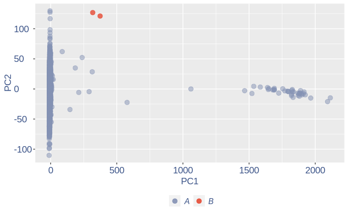

```r
obj = ttm$object

ttm$pca.cell.2
```

Run this when B cells need to be removed.

```r
pdf(paste(out_dir,"cleaning/",t,"_",n_it,"_plots_before_cells_exlusion.pdf", sep = ""))
ttm$pca.cell.2
ggplot(ttm$D, aes(x=n,y=means)) + geom_point() +
  geom_text_repel(data=subset(ttm$D, n > (max(ttm$D$n)- 15) ), aes(n,means,label=rownames(ttm$D[ttm$D$n > (max(ttm$D$n)- 15),])),
                  nudge_y      = 0.05,
                  nudge_x      = 0.05,
                  direction    = "x",
                  angle        = 90,
                  vjust        = 0,
                  segment.size = 0.2)+
  ggtitle("B cell group genes mean expression")+my_theme +
  theme(plot.title = element_text(color = "#3C5488FF", size = 20, face = "italic",vjust = - 5,hjust = 0.02 ))
```

```r
dev.off()
```

```r
if (length(ttm$cl1) < length(ttm$cl2)) {
  to_rem = ttm$cl1
}else{
  to_rem = ttm$cl2
}
n_it = n_it+1
obj@raw = obj@raw[,!colnames(obj@raw) %in% to_rem]
#obj@raw = obj@raw[rownames(obj@raw) %in% rownames(cells),colnames(obj@raw) %in% colnames(cells)]
gc()
```

```
             used   (Mb) gc trigger    (Mb)   max used    (Mb)
Ncells    4018873  214.7    7357374   393.0    6673363   356.4
Vcells 1052909001 8033.1 1518884376 11588.2 1518884266 11588.2
```

```r
ttm = clean(obj)
```

```
[1] "Start estimation mu with linear method"
[1] 13718 11067
```

|  | rowname | e14-WT10_CCATCCGTTGAT | e14-WT11_AGTGAAATCCTA | e14-WT8-1_AAAGAACTTAAG | e14-WT8-2_CCATCAATAGAA | e14-WT8-2_CGCTTCCTCCTC | e14-WT8-2_CTAACTTAATAC | e14-WT8-2_TAGTCAGTTCAT |
| --- | --- | --- | --- | --- | --- | --- | --- | --- |
| 5787 | Hbb-bs | 2012.644045 | 2014.140334 | 1778.831015 | 1402.254203 | 1772.939306 | 1966.495934 | 1531.577462 |
| 5784 | Hba-a1 | 472.811617 | 343.563383 | 482.094689 | 536.773118 | 411.098786 | 374.704813 | 512.110074 |
| 5788 | Hbb-bt | 444.059559 | 599.804406 | 415.191752 | 244.782529 | 371.080320 | 307.088907 | 430.124935 |
| 5785 | Hba-a2 | 309.883289 | 257.672537 | 403.385352 | 437.111659 | 266.789772 | 253.559648 | 367.150842 |
| 12559 | Tuba1a | 9.584019 | 2.863028 | 3.935467 | 13.987573 | 7.276085 | 5.634659 | 3.564571 |
| 8457 | Pabpc1 | 0.000000 | 5.726056 | 11.806401 | 1.748447 | 0.000000 | 0.000000 | 15.446476 |
| 7064 | Map1b | 0.000000 | 2.863028 | 5.903200 | 5.245340 | 3.638042 | 14.086647 | 0.000000 |
| 10253 | Rps2 | 0.000000 | 1.431514 | 7.870934 | 3.496893 | 0.000000 | 16.903977 | 1.188190 |
| 7037 | Malat1 | 0.000000 | 0.000000 | 3.935467 | 6.993787 | 10.914127 | 5.634659 | 2.376381 |
| 787 | Actb | 3.194673 | 1.431514 | 3.935467 | 8.742233 | 6.063404 | 2.817329 | 1.188190 |

[output cut: 5 more lines]

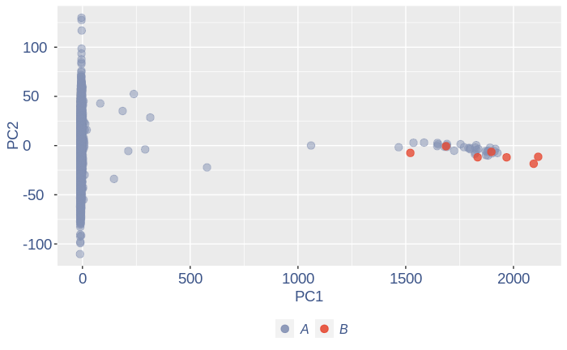

```r
#ttm = clean.sqrt(obj, cells)
obj = ttm$object

ttm$pca.cell.2
```

[output not shown]

|  | rowname | e14-WT10_AGGGCATTTGTG | e14-WT10_CGTATGCACTCG | e14-WT10_GTTATACAATGC | e14-WT10_TAAAGATTGTAA | e14-WT11_ACCTGTCTCAGA | e14-WT8-1_TGGCGGATGAGA | e14-WT9-1_CGTGAATAGTAC | e14-WT9-1_GACGTTTTTCAG | e14-WT9-1_GCCACCCTGAAC | e14-WT9-1_GGTGCGAAAATC | e14-WT9-2_CCGCGTACAAAG |
| --- | --- | --- | --- | --- | --- | --- | --- | --- | --- | --- | --- | --- |
| 12554 | Ttr | 574.600871 | 1152.508633 | 1057.088055 | 370.823007 | 1203.605551 | 717.241538 | 622.721335 | 536.027646 | 417.3591554 | 387.243703 | 457.884548 |
| 7037 | Malat1 | 23.335319 | 24.379990 | 30.559707 | 41.440721 | 26.728791 | 14.533224 | 14.663768 | 11.245335 | 20.4724669 | 67.556534 | 14.907869 |
| 6156 | Igfbp2 | 16.435090 | 24.749384 | 12.501698 | 5.001466 | 27.538754 | 17.762830 | 5.865507 | 3.748445 | 13.0279335 | 12.063667 | 2.129696 |
| 6043 | Hsp90ab1 | 10.036696 | 5.540907 | 1.389078 | 22.863846 | 8.504615 | 11.303619 | 7.038608 | 18.742225 | 14.4237835 | 9.650933 | 14.907869 |
| 787 | Actb | 6.649311 | 11.081814 | 11.112621 | 5.715962 | 5.669744 | 6.997478 | 7.234125 | 11.245335 | 22.3336003 | 21.714600 | 10.648478 |
| 1855 | Bsg | 17.815136 | 20.686052 | 12.501698 | 7.859447 | 22.678974 | 12.380154 | 5.865507 | 3.748445 | 4.1875501 | 4.825467 | 2.129696 |
| 11255 | Sostdc1 | 8.907568 | 20.686052 | 22.225242 | 7.859447 | 10.124542 | 9.957950 | 4.105855 | 0.000000 | 16.2849169 | 3.619100 | 0.000000 |
| 6433 | Kcne2 | 10.413073 | 9.604239 | 13.890776 | 3.572476 | 10.934505 | 10.765351 | 13.490666 | 14.993780 | 0.4652833 | 2.412733 | 10.648478 |
| 2817 | Cox4i1 | 7.151146 | 8.126663 | 9.723543 | 5.001466 | 9.719560 | 9.688816 | 8.211710 | 22.490670 | 6.0486834 | 4.825467 | 6.389087 |
| 10998 | Slc6a15 | 13.047705 | 7.387876 | 12.501698 | 5.001466 | 12.554432 | 11.841887 | 13.686183 | 0.000000 | 2.3264167 | 6.031833 | 12.778173 |

[output cut: 5 more lines]

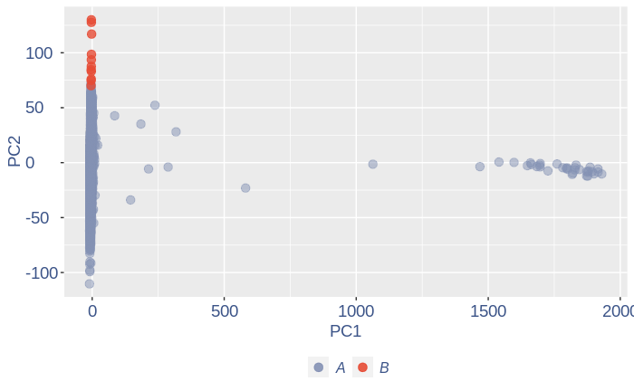

[output not shown]

|  | rowname | e14-WT10_ATCGTAAGTTGA | e14-WT10_CGTGCCTGAGCC | e14-WT10_CGTGGAAAGTAC | e14-WT10_CTAAAGCGTCTG | e14-WT10_CTTTTTCCCCCA | e14-WT11_CAATTAGCTGTC | e14-WT11_CTAGGCGCTTCA | e14-WT11_CTCCTAACGGTN | e14-WT11_GATTGCTGCGCT | e14-WT11_GCATACAAGATC | e14-WT11_GCGTCGTCGCTC | e14-WT11_GGTCGCTTCCTT | e14-WT11_GTTCAAAGGCGC | e14-WT11_TGTTACTTTTGT | e14-WT11_TTATACACTGAT | e14-WT11_TTCATAAGCTCT | e14-WT11_TTGCTTATTCCN | e14-WT8-1_AAGTTTCAGCCG | e14-WT8-1_CACTAAGTCTCC | e14-WT8-1_CTACACACTGAT | e14-WT8-1_GAAACCCGGTCG | e14-WT8-1_TTACAATGACCA | e14-WT8-1_TTCGCATAGGTT | e14-WT8-2_AACGATTAGTCN | e14-WT8-2_CCTCTCGTCGGG | e14-WT8-2_CTGGGGTGATGT | e14-WT8-2_GGCACCGTATGG | e14-WT9-1_ATTATCACTACA | … |
| --- | --- | --- | --- | --- | --- | --- | --- | --- | --- | --- | --- | --- | --- | --- | --- | --- | --- | --- | --- | --- | --- | --- | --- | --- | --- | --- | --- | --- | --- | --- |
| 5775 | Hbb-bs | 1682.041404 | 1290.677184 | 1323.494152 | 1592.232384 | 1629.3932719 | 1402.5033117 | 1549.5086779 | 1249.031355 | 1660.377269 | 1692.610503 | 1436.258409 | 1544.013186 | 1629.473121 | 1416.9124496 | 1627.893047 | 1664.809667 | 1418.0806178 | 1519.291499 | 1689.564912 | 1420.433130 | 1708.064242 | 889.783883 | 486.633003 | 1220.913353 | 1531.321089 | 1684.388974 | 1582.220151 | 1322.492721 | … |
| 5776 | Hbb-bt | 847.748868 | 587.152326 | 925.728288 | 904.520565 | 713.0455036 | 639.0611420 | 706.5077105 | 850.505421 | 720.472075 | 723.937556 | 734.401014 | 883.994055 | 771.608061 | 715.3898781 | 633.436856 | 649.978450 | 729.9503448 | 696.721912 | 719.271920 | 745.464050 | 620.898004 | 433.349934 | 264.728354 | 628.747513 | 793.822772 | 578.883084 | 670.116770 | 893.634999 | … |
| 5772 | Hba-a1 | 341.454405 | 314.734805 | 387.514167 | 411.522334 | 466.1076310 | 444.6264322 | 462.9913317 | 437.131278 | 409.608489 | 362.824496 | 419.812692 | 391.398041 | 417.170212 | 447.8324323 | 412.593526 | 309.449199 | 462.5553400 | 373.895267 | 431.241330 | 426.210968 | 409.174164 | 322.651585 | 150.531809 | 617.315740 | 499.879528 | 554.762956 | 532.370545 | 391.849695 | … |
| 5773 | Hba-a2 | 290.993163 | 237.153116 | 277.821003 | 294.141802 | 372.8861048 | 402.4512561 | 366.0500981 | 374.768799 | 305.987294 | 335.441515 | 317.842684 | 327.405206 | 302.683650 | 353.2084575 | 341.183108 | 256.748244 | 363.0742601 | 244.399833 | 352.394967 | 367.870303 | 309.259542 | 249.202444 | 121.723135 | 472.132224 | 362.588672 | 373.861992 | 362.979917 | 333.072241 | … |
| 8441 | Pabpc1 | 0.000000 | 6.171271 | 14.352377 | 2.761895 | 0.9917184 | 38.6010086 | 13.1840078 | 30.290347 | 3.657219 | 1.711436 | 28.204470 | 17.858466 | 31.366181 | 19.5773741 | 30.415548 | 13.513065 | 32.3155101 | 14.591035 | 1.609109 | 21.877749 | 14.273517 | 12.591281 | 3.114451 | 3.429532 | 0.000000 | 34.170182 | 0.000000 | 6.530828 | … |
| 5592 | Gpx1 | 5.046124 | 15.868982 | 62.535355 | 11.047579 | 0.0000000 | 28.5933397 | 3.8776493 | 35.041774 | 4.876292 | 0.000000 | 24.950108 | 3.720514 | 0.000000 | 40.7861960 | 14.546567 | 0.000000 | 9.5045618 | 14.591035 | 12.872876 | 39.704064 | 14.273517 | 9.443461 | 19.984395 | 1.143177 | 15.841253 | 0.000000 | 1.861435 | 25.034842 | … |
| 4517 | Fth1 | 8.410207 | 22.921863 | 16.402716 | 9.666632 | 0.0000000 | 4.2890010 | 9.3063584 | 21.381421 | 9.752583 | 1.711436 | 10.847873 | 5.952822 | 3.136618 | 13.8673066 | 1.322415 | 10.810452 | 17.1082112 | 1.823879 | 17.700204 | 22.688036 | 26.168115 | 11.542008 | 7.267053 | 2.286355 | 1.760139 | 2.010011 | 0.000000 | 7.619300 | … |
| 993 | Alas2 | 5.046124 | 6.171271 | 14.352377 | 4.142842 | 3.9668735 | 15.0115033 | 6.2042390 | 20.193564 | 9.752583 | 1.711436 | 18.441384 | 8.185130 | 6.273236 | 16.3144784 | 9.256906 | 0.000000 | 6.9700120 | 1.823879 | 9.654657 | 14.585166 | 9.515678 | 4.197094 | 4.412139 | 11.431773 | 14.081113 | 6.030032 | 5.584306 | 6.530828 | … |
| 12534 | Tuba1a | 3.364083 | 8.816101 | 4.100679 | 4.142842 | 10.9089020 | 4.2890010 | 3.1021195 | 2.969642 | 6.095364 | 6.845745 | 1.084787 | 2.976411 | 4.704927 | 5.7100674 | 7.934491 | 6.756533 | 5.0690996 | 7.295517 | 0.000000 | 1.620574 | 4.757839 | 15.739102 | 48.793069 | 4.572709 | 1.760139 | 0.000000 | 1.861435 | 1.088471 | … |
| 9265 | Prdx2 | 1.682041 | 7.052881 | 9.226528 | 4.142842 | 0.0000000 | 2.8593340 | 3.1021195 | 5.939284 | 3.657219 | 0.000000 | 5.423937 | 1.488205 | 1.568309 | 2.4471718 | 1.322415 | 2.702613 | 8.2372869 | 1.823879 | 1.609109 | 11.344018 | 11.894598 | 8.394188 | 9.602891 | 1.143177 | 0.000000 | 4.020021 | 0.000000 | 5.442357 | … |

[output cut: 5 more lines]

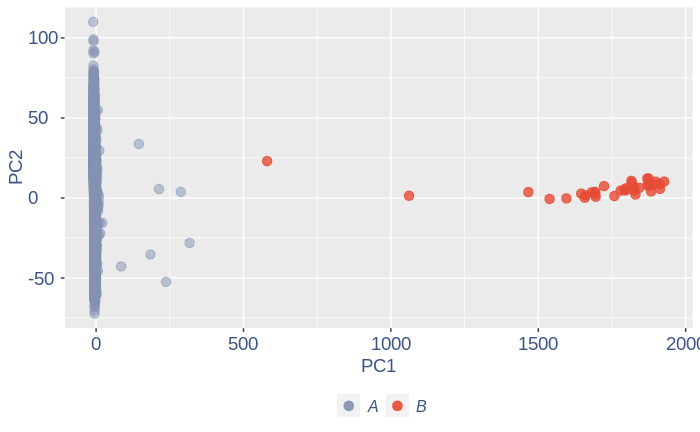

[output not shown]

|  | rowname | e14-WT10_AGAGCTGGACGT | e14-WT10_ATGTGTAGTCAC | e14-WT10_CAGCGTCTGTTC | e14-WT10_CATGGTAAGACC | e14-WT10_CTGAATGCAGCG | e14-WT10_GGCACATCAGCG | e14-WT10_TACATACAATGG | e14-WT10_TACGACGAATTA | e14-WT10_TAGACCGCTTGA | e14-WT10_TCGACTCATGTG | e14-WT10_TTACGCAACCAT | e14-WT10_TTTCCCCAATAA | e14-WT11_ACGATGGTGCAG | e14-WT11_TAACCACGGGTA | e14-WT11_TACAAGAAGTCC | e14-WT11_TGAAAAGCAGAG | e14-WT8-1_AAAATCCATGGC | e14-WT8-1_ACCCACACTATC | e14-WT8-1_ATATCCATTACC | e14-WT8-1_ATCCACCAGTGG | e14-WT8-1_CCATAGTATTCG | e14-WT8-1_GACACGGGACCC | e14-WT8-1_GGCTACTGTGGT | e14-WT8-1_GGGGACGTGCAA | e14-WT8-1_TACATGATCGAT | e14-WT8-1_TCGTTTAGCGGC | e14-WT8-1_TGTCACTAAAAG | e14-WT8-1_TTGGAGGCTATA | … |
| --- | --- | --- | --- | --- | --- | --- | --- | --- | --- | --- | --- | --- | --- | --- | --- | --- | --- | --- | --- | --- | --- | --- | --- | --- | --- | --- | --- | --- | --- | --- |
| 7250 | Meg3 | 84.361212 | 77.714463 | 68.956688 | 119.947404 | 66.998755 | 139.998257 | 120.466294 | 131.6680 | 35.565303 | 89.584426 | 53.415313 | 71.285877 | 91.496357 | 64.512359 | 55.518278 | 119.025119 | 76.048920 | 139.858973 | 50.005825 | 59.312903 | 128.085854 | 91.00924 | 103.337855 | 41.655972 | 211.276079 | 34.514510 | 81.621262 | 65.632645 | … |
| 7019 | Malat1 | 62.160893 | 70.649512 | 62.252565 | 119.947404 | 22.332918 | 101.816914 | 102.750662 | 184.3352 | 97.804583 | 39.522541 | 67.150679 | 27.218244 | 16.805453 | 22.769068 | 17.664907 | 45.342902 | 59.752723 | 110.922634 | 53.131189 | 44.484677 | 12.198653 | 52.68956 | 79.490657 | 21.924196 | 28.998678 | 49.306443 | 31.392793 | 32.816323 | … |
| 12530 | Tuba1a | 39.960574 | 14.129902 | 31.605149 | 28.683075 | 33.499377 | 0.000000 | 24.801884 | 26.3336 | 120.032898 | 97.488935 | 83.938349 | 9.072748 | 54.150905 | 22.769068 | 27.759139 | 17.003588 | 16.296197 | 4.822723 | 65.632645 | 51.898790 | 6.099326 | 23.94980 | 7.949066 | 6.577259 | 16.570673 | 83.820953 | 25.114234 | 56.256553 | … |
| 7046 | Map1b | 0.000000 | 21.194854 | 2.873195 | 5.215105 | 9.571251 | 6.363557 | 7.086253 | 26.3336 | 4.445663 | 7.904508 | 15.261518 | 9.072748 | 16.805453 | 53.127825 | 8.832453 | 17.003588 | 10.864131 | 4.822723 | 14.064138 | 14.828226 | 24.397306 | 4.78996 | 15.898131 | 0.000000 | 82.853364 | 9.861289 | 9.417838 | 18.752184 | … |
| 8082 | Nnat | 4.440064 | 7.064951 | 16.281440 | 18.252866 | 19.142501 | 12.727114 | 7.086253 | 16.4585 | 4.445663 | 10.539344 | 9.156911 | 5.184427 | 22.407271 | 3.794845 | 22.712023 | 22.671451 | 38.024460 | 0.000000 | 3.125364 | 3.707056 | 6.099326 | 14.36988 | 3.974533 | 0.000000 | 0.000000 | 9.861289 | 25.114234 | 0.000000 | … |
| 11119 | Snhg11 | 39.960574 | 0.000000 | 20.112367 | 65.188807 | 17.547293 | 25.454229 | 0.000000 | 13.1668 | 4.445663 | 0.000000 | 0.000000 | 0.000000 | 16.805453 | 0.000000 | 35.329813 | 0.000000 | 21.728263 | 28.936339 | 0.000000 | 0.000000 | 12.198653 | 0.00000 | 3.974533 | 0.000000 | 57.997355 | 0.000000 | 0.000000 | 0.000000 | … |
| 12492 | Ttc3 | 22.200319 | 14.129902 | 10.535050 | 0.000000 | 17.547293 | 0.000000 | 3.543126 | 6.5834 | 8.891326 | 5.269672 | 3.052304 | 2.592214 | 1.867273 | 7.589689 | 10.094232 | 5.667863 | 10.864131 | 14.468170 | 10.938774 | 3.707056 | 6.099326 | 9.57992 | 15.898131 | 0.000000 | 16.570673 | 9.861289 | 3.139279 | 4.688046 | … |
| 785 | Actb | 13.320191 | 14.129902 | 14.365977 | 2.607552 | 13.559272 | 6.363557 | 3.543126 | 3.2917 | 4.445663 | 5.269672 | 10.683063 | 14.257175 | 22.407271 | 0.000000 | 22.712023 | 17.003588 | 5.432066 | 4.822723 | 7.813410 | 22.242339 | 0.000000 | 9.57992 | 7.949066 | 28.501454 | 0.000000 | 19.722577 | 9.417838 | 4.688046 | … |
| 5609 | Gria2 | 0.000000 | 28.259805 | 9.577318 | 13.037761 | 0.000000 | 0.000000 | 7.086253 | 13.1668 | 4.445663 | 5.269672 | 6.104607 | 1.296107 | 5.601818 | 11.384534 | 2.523558 | 22.671451 | 5.432066 | 28.936339 | 7.813410 | 0.000000 | 6.099326 | 14.36988 | 3.974533 | 4.384839 | 8.285336 | 0.000000 | 21.974955 | 0.000000 | … |
| 5960 | Hnrnpa2b1 | 17.760255 | 21.194854 | 10.535050 | 7.822657 | 1.595208 | 6.363557 | 7.086253 | 3.2917 | 22.228314 | 7.904508 | 7.630759 | 5.184427 | 5.601818 | 7.589689 | 18.926686 | 0.000000 | 0.000000 | 4.822723 | 3.125364 | 0.000000 | 0.000000 | 14.36988 | 11.923599 | 2.192420 | 4.142668 | 4.930644 | 12.557117 | 14.064138 | … |

[output cut: 5 more lines]

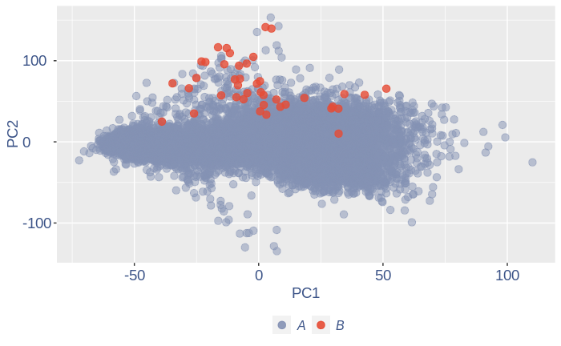

Run this only in the last iteration, instead the previous code, when B cells group has not to be removed.

```r
pdf(paste(out_dir,"cleaning/",t,"_",n_it,"_plots_before_cells_exlusion.pdf", sep = ""))
ttm$pca.cell.2
ggplot(ttm$D, aes(x=n,y=means)) + geom_point() +
  geom_text_repel(data=subset(ttm$D, n > (max(ttm$D$n)- 15) ), aes(n,means,label=rownames(ttm$D[ttm$D$n > (max(ttm$D$n)- 15),])),
                  nudge_y      = 0.05,
                  nudge_x      = 0.05,
                  direction    = "x",
                  angle        = 90,
                  vjust        = 0,
                  segment.size = 0.2)+
  ggtitle(label = "B cell group genes mean expression", subtitle = " - B group NOT removed -")+my_theme +
  theme(plot.title = element_text(color = "#3C5488FF", size = 20, face = "italic",vjust = - 10,hjust = 0.02 ),
        plot.subtitle = element_text(color = "darkred",vjust = - 15,hjust = 0.01 ))
```

```r
dev.off()
```

To colour the pca based on nu_j (so the cells’ efficiency).

```r
nu_est = round(obj@nu, digits = 7)

plot.nu <-ggplot(ttm$pca_cells,aes(x=PC1,y=PC2, colour = log(nu_est)))

plot.nu = plot.nu + geom_point(size = 1,alpha= 0.8)+
  scale_color_gradient2(low = "#E64B35B2",mid =  "#4DBBD5B2", high =  "#3C5488B2" ,
                        midpoint = log(mean(nu_est)),name = "ln (nu)")+
  ggtitle("Cells PCA coloured by cells efficiency") +
  my_theme +  theme(plot.title = element_text(color = "#3C5488FF", size = 20),
                    legend.title=element_text(color = "#3C5488FF", size = 14,face = "italic"),
                    legend.text = element_text(color = "#3C5488FF", size = 11),
                    legend.key.width = unit(2, "mm"),
                    legend.position="right")

pdf(paste(out_dir,"cleaning/",t,"_plots_PCA_efficiency_colored.pdf", sep = ""))
plot.nu
dev.off()
```

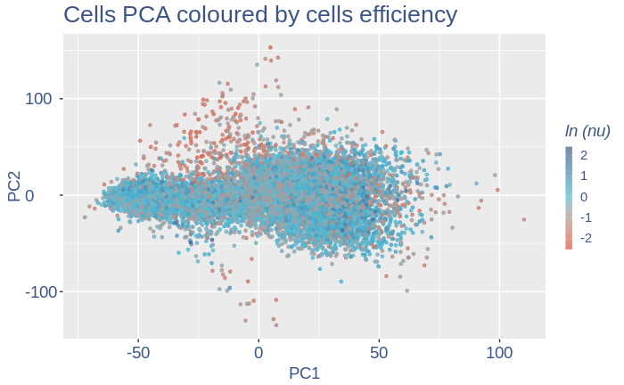

```r
plot.nu
```

The next part is used to remove the cells with efficiency too low.

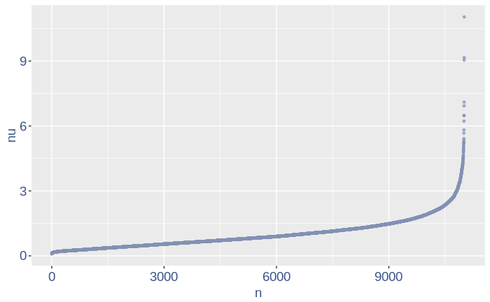

```r
nu_df = data.frame("nu"= sort(obj@nu), "n"=c(1:length(obj@nu)))

ggplot(nu_df, aes(x = n, y=nu)) +
    geom_point(colour = "#8491B4B2", size=1)+
    my_theme #+ ylim(0,1) + xlim(0,70)
```

We can zoom on the smallest values and, if we detect a clear elbow, we can decide to remove the cells.

```r
yset = 0.18#threshold to remove low UDE cells
plot.ude <- ggplot(nu_df, aes(x = n, y=nu)) +
    geom_point(colour = "#8491B4B2", size=1) +
    my_theme + ylim(0.,0.7) + xlim(0,2000) +
    geom_hline(yintercept=yset, linetype="dashed", color = "darkred") +
    annotate(geom="text", x=500, y=0.5,
             label=paste("to remove cells with nu < ",yset,sep = " "),
             color="darkred", size=4.5)


pdf(paste(out_dir,"cleaning/",t,"_plots_efficiency.pdf", sep = ""))
plot.ude
dev.off()
```

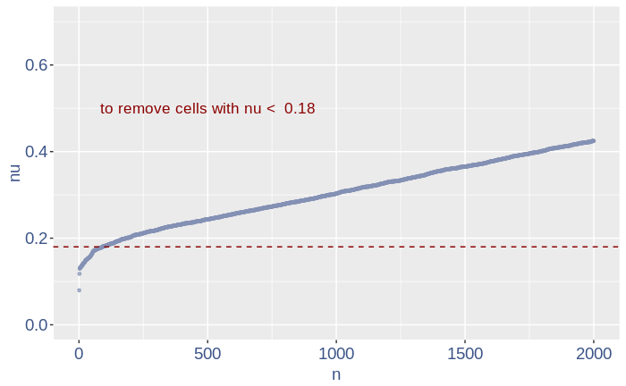

```r
plot.ude
```

We also save the defined threshold in the metadata and re-run the estimation.

```r
obj@meta[(nrow(obj@meta)+1),1:2] = c("Threshold low UDE cells:",yset)

to_rem = rownames(nu_df[which(nu_df$nu < yset),])

obj@raw = obj@raw[, !colnames(obj@raw) %in% to_rem]
```

Repeat the estimation after the cells are removed.

```r
ttm = clean(obj)
```

```
[1] "Start estimation mu with linear method"
[1] 13683 10923
```

|  | rowname | e14-WT8-1_TACATGATCGAT | e14-WT8-2_TCCTAGCCTGGT |
| --- | --- | --- | --- |
| 7247 | Meg3 | 212.756855 | 205.079707 |
| 7016 | Malat1 | 29.201921 | 89.614662 |
| 11116 | Snhg11 | 58.403843 | 46.530690 |
| 7043 | Map1b | 83.434061 | 8.616794 |
| 12489 | Ttc3 | 16.686812 | 25.850383 |
| 7047 | Map2 | 16.686812 | 17.233589 |
| 3598 | Dync1i2 | 20.858515 | 5.170077 |
| 5769 | Hbb-bs | 0.000000 | 25.850383 |
| 936 | Ahi1 | 8.343406 | 15.510230 |
| 10627 | Sf3b1 | 16.686812 | 6.893436 |

[output cut: 5 more lines]

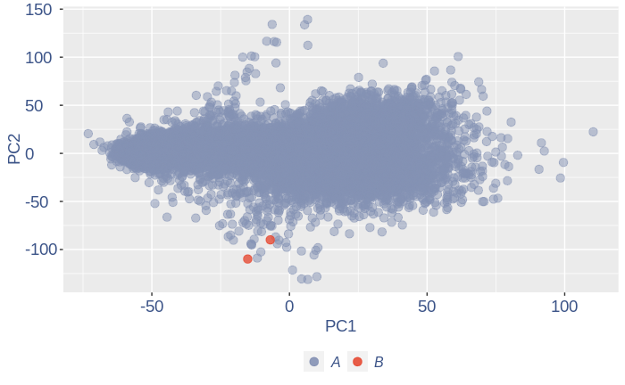

```r
obj = ttm$object
ttm$pca.cell.2
```

Just to check again, we plot the final efficiency coloured PCA.

```r
nu_est = round(obj@nu, digits = 7)
plot.nu <-ggplot(ttm$pca_cells,aes(x=PC1,y=PC2, colour = log(nu_est)))
plot.nu = plot.nu + geom_point(size = 2,alpha= 0.8)+
  scale_color_gradient2(low = "#E64B35B2",mid =  "#4DBBD5B2", high =  "#3C5488B2" ,
                        midpoint = log(mean(nu_est)),name = "ln(nu)")+
  ggtitle("Cells PCA coloured by cells efficiency: last") +
  my_theme +  theme(plot.title = element_text(color = "#3C5488FF", size = 20),
                    legend.title=element_text(color = "#3C5488FF", size = 14,face = "italic"),
                    legend.text = element_text(color = "#3C5488FF", size = 11),
                    legend.key.width = unit(2, "mm"),
                    legend.position="right")

pdf(paste(out_dir,"cleaning/",t,"_plots_PCA_efficiency_colored_FINAL.pdf", sep = ""))
plot.nu
dev.off()
```

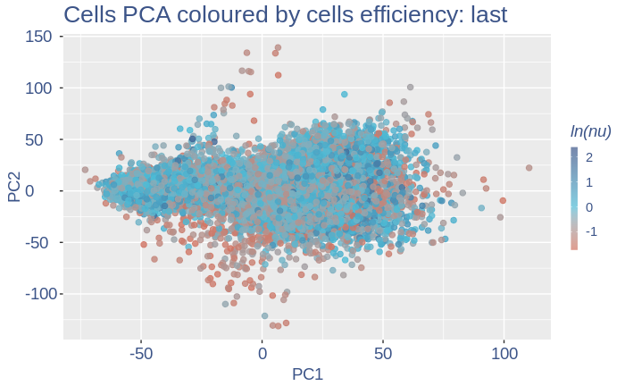

```r
plot.nu
```

COTAN analysis: in this part all the contingency tables are computed and used to get the statistics (S) To storage efficiency of all the observed tables only the yes_yes is stored. Note that if will be necessary re-computing the yes-yes table, the yes-yes table should be cancelled before running cotan_analysis.

```r
# obj@yes_yes = c()
obj = cotan_analysis(obj)
```

COEX evaluation and storing

```r
saveRDS(obj,file = paste(out_dir,t,".cotan.RDS", sep = ""))

obj = get.coex(obj)

# saving the structure
saveRDS(obj,file = paste(out_dir,t,".cotan.RDS", sep = ""))
```

## 0.3 Elaborated data analysis

### 0.3.1 GDI

The next function can directly plot the GDI for the dataset with the 1.5 threshold (in red) and the two higher quantiles (in blue).

```r
plot_GDI(obj, cond = "E14.5")
```

```
[1] "GDI plot "
[1] "function to generate GDI dataframe"
[1] "Using S"
[1] "function to generate S "
```

If a more complex plot is needed, or if we want to analyse mor in detail the GDI data, we can get directly the GDI data frame.

```r
quant.p = get.GDI(obj)
```

```
[1] "function to generate GDI dataframe"
[1] "Using S"
[1] "function to generate S "
```

In the third column of this dataframe is reported the percentage of cells expressing the gene.

```r
NPGs=c("Nes","Vim","Sox2","Sox1","Notch1", "Hes1","Hes5","Pax6") #,"Hes3"
PNGs=c("Map2","Tubb3","Neurod1","Nefm","Nefl","Dcx","Tbr1")
hk=c("Calm1","Cox6b1","Ppia","Rpl18","Cox7c","Erh","H3f3a","Taf1","Taf2","Gapdh","Actb","Golph3", "Mtmr12", "Zfr", "Sub1", "Tars", "Amacr")

text.size = 12

quant.p$highlight = with(quant.p, ifelse(rownames(quant.p) %in% NPGs, "NPGs",
                                                 ifelse(rownames(quant.p) %in% hk,"Constitutive" ,
                                                               ifelse(rownames(quant.p) %in% PNGs,"PNGs" , "normal"))))

textdf <- quant.p[rownames(quant.p) %in% c(NPGs,hk,PNGs), ]
mycolours <- c("Constitutive" = "#00A087FF","NPGs"="#E64B35FF","PNGs"="#F39B7FFF","normal" = "#8491B4B2")
f1 = ggplot(subset(quant.p,highlight == "normal" ), aes(x=sum.raw.norm, y=GDI)) +  geom_point(alpha = 0.1, color = "#8491B4B2", size=2.5)
GDI_plot = f1 +  geom_point(data = subset(quant.p,highlight != "normal"  ), aes(x=sum.raw.norm, y=GDI, colour=highlight),size=2.5,alpha = 0.8) +
  geom_hline(yintercept=quantile(quant.p$GDI)[4], linetype="dashed", color = "darkblue") +
  geom_hline(yintercept=quantile(quant.p$GDI)[3], linetype="dashed", color = "darkblue") +
  geom_hline(yintercept=1.5, linetype="dotted", color = "red", size= 0.5) +
  scale_color_manual("Status", values = mycolours)  +
  scale_fill_manual("Status", values = mycolours)  +
  xlab("log normalized counts")+ylab("GDI")+
  geom_label_repel(data =textdf , aes(x=sum.raw.norm, y=GDI, label = rownames(textdf),fill=highlight),
                   label.size = NA,
                   alpha = 0.5,
                   direction ="both",
                   na.rm=TRUE,
                   seed = 1234) +
  geom_label_repel(data =textdf , aes(x=sum.raw.norm, y=GDI, label = rownames(textdf)),
                   label.size = NA,
                   segment.color = 'black',
                   segment.size = 0.5,
                   direction = "both",
                   alpha = 0.8,
                   na.rm=TRUE,
                   fill = NA,
                   seed = 1234) +
  theme(axis.text.x = element_text(size = text.size, angle = 0, hjust = .5, vjust = .5, face = "plain", colour ="#3C5488FF" ),
        axis.text.y = element_text( size = text.size, angle = 0, hjust = 0, vjust = .5, face = "plain", colour ="#3C5488FF"),
        axis.title.x = element_text( size = text.size, angle = 0, hjust = .5, vjust = 0, face = "plain", colour ="#3C5488FF"),
        axis.title.y = element_text( size = text.size, angle = 90, hjust = .5, vjust = .5, face = "plain", colour ="#3C5488FF"),
        legend.title = element_blank(),
        legend.text = element_text(color = "#3C5488FF",face ="italic" ),
        legend.position = "bottom")  # titl)
legend <- cowplot::get_legend(GDI_plot)
GDI_plot =GDI_plot + theme(
        legend.position = "none")
GDI_plot
```

[output not shown]

### 0.3.2 Heatmaps

For the Gene Pair Analysis, we can plot an heatmap with the coex values between two genes sets. To do so we need to define, in a list, the different gene sets (list.genes). Then in the function parameter sets we can decide which sets need to be considered (in the example from 1 to 3). In the condition parameter we should insert an array with each file name prefix to be considered (in the example, the file names is “E14_cortex”).

```r
list.genes = list("Ref.col"= PNGs, "NPGs"=NPGs, "Const."=hk )

plot_heatmap(df_genes = list.genes,sets = c(1:3),conditions = "E14_cortex",dir = "Data/")
```

[output not shown]